# Praktisk info

Emnet bygger videre på Elektriske anlegg og installasjoner 1. Emnet vil være ca. 50% prosjektarbeid og caseløsning i grupper (problem/challenge based learning) og 50% forelesninger som støtter opp om prosjektarbeidet og som bygger videre på tema fra elektriske anlegg og installasjoner 1, som beskrevet i [emneplanen](https://www.uis.no/nb/course/ELK330_1?semester=2026H)

#### Innhold

Det faglige innholdet i dette emnet er todelt, i tillegg til å inkludere prosjektarbeid.

Elektriske anlegg:

Introduksjon til **modellering** av transmisjonsliner og 3-fase-systemer. Dette inkluderer last- og kortslutningsberegninger, belastningsfordeling, samt spenningsfall, effekt- og energitap. Emnet inkluderer videre analyse og simulering av dynamisk oppførsel. Emnet gir en oversikt over vern for distribusjonssystemer og i nettet, samt beskyttelse av kabler, generatorer og motorer.

Prosjektarbeid og faglig ledelse:

Studentene deles inn i grupper og sammen skal de arbeide praktisk med å prosjektere ulike elektriske anlegg av ulik størrelse og kompleksitet.

#### Forkunnskapskrav

Elektroteknikk (ELE100) Elektriske anlegg og installasjoner 1 (ELK220)

#### Anbefalte forkunnskaper

Smarte nett med distribuert produksjon og ladeinfrastruktur (ELK250)

#### Skriftlig eksamen

Vekt 3/5

Varighet 4 Timer

Karakter Bokstavkarakterer

Hjelpemiddel Bestemt enkel kalkulator

Eksamenssystem Papirbasert

Rapport Vekt 2/5

Karakter Bokstavkarakterer

Eksamenssystem Canvas

#### Rapport

Rapporten beskriver og dokumenterer arbeid i prosjektdelen. Rapporten kan skrives individuelt eller i gruppen på maksimalt 4 studenter. Dersom rapporten skrives i gruppe, vil alle deltakerne i gruppen få felles karakter. Det tilbys ikke kontinuasjonsmuligheter på rapporten. Studenter som ikke består rapporten, kan ta denne delen på nytt neste gang emnet har ordinær undervisning

##### Vilkår for å gå opp til eksamen/vurdering

Øvinger:

6 av 10 obligatoriske teoriøvinger må være godkjent.

LAB:

8 av 10 obligatoriske labøvinger må være godkjent.

##### Arbeidsformer

6 timer forelesning, 2 timer regneøvinger og 2 timer lab pr uke.

Prosjektdelen går over hele semester i parallell med undervisningen.

Under er den allokerte [timeplanen](https://tp.educloud.no/uis/app/schedule?semester=26h&scheduleType=studentGroup&filterOpen=true&summary=true&pastWeeks=false&tab=calendar&studentGroup=193&subjectArea=217080400), men av praktiske årsaker vil denne modifiseres.

Alle forandringer kommuniseres i emnets rom på [canvas](https://stavanger.instructure.com/courses/18261)

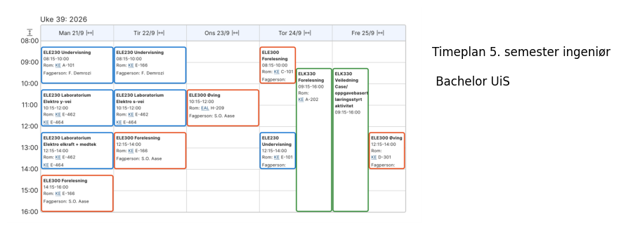

# Om meg

[figure not shown]

# Kontakt meg

📧nils.j.johannesen@usn.no

📧nils.j.johannesen@uis.no

🌐 [website](https://www.usn.no/english/about/contact-us/employees/nils-jakob-johannesen)

Veibeskrivelse til A-202

[interactive chart not shown]

# Fra idé til ELK330

I prosessen med å lage emne ELK330 ble jeg inspirert av Porfessor Mattia Marinelli ved Dansk Teknisk Universitet (DTU), som har laget et tilsvarende emne på DTU.

Han hadde to ledesnorerunder utviklingen av emnet:

1. Hva slags kurs ville jeg selv ønsket å ta som student
2. Hva kan jeg bidra med fra min egen bakgrunn/ekspertise inn i faget

Punkt 1 har jeg alltid som student ønsket meg verktøy i fra utdanningen jeg kan ta med meg videre.

- Git
- Power Factory

Punkt 2 vil jeg bringe inn min bakgrunn med applikert maskinlæring og dataanalyse. En av grunnene til at jeg valgte å studere maskinlæring i mine master-studier var at jeg ønsket et verktøy.

# Støttelitteratur ELK330

Anbefalt litteratur for emnet.

ELK 330 bygger på alle erfaringer så langt i studieløpet.

En målsetning er å få benyttet tidligere erfaringer, sammensette de på en ny måte, til å oppdage kraftnettet på nytt.

ELK330 bygger både på kunnskaper fra fellesemnene og elkraft-emnene som beskrevet i studieplanen:

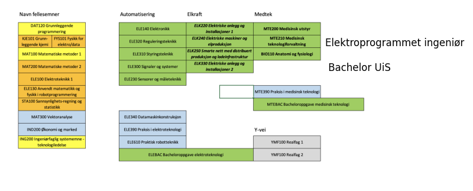

[figure not shown]

[figure not shown]

[figure not shown]

[figure not shown]

[figure not shown]

[figure not shown]

# Timeplan ELK330

[figure not shown]